# Chapter 11 excercises

Hugo Åkerstrand

2023-09-11

```r
library(tidyverse)
```

```r
library(nycflights13)
library(lvplot)
library(hexbin)
```

### 11.3.3

There is a large majority of diamonds that have similar measurements in all dimensions.

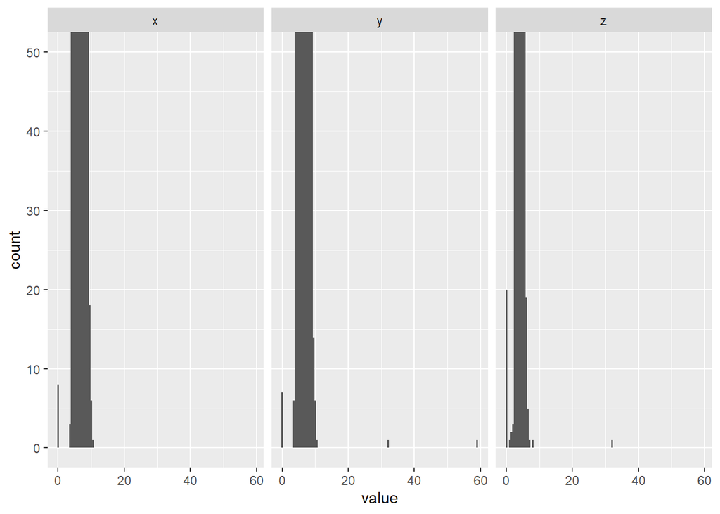

```r
diamonds |>
  select(x:z) |>
  pivot_longer(where(is.numeric), names_to = "variable") |>
  ggplot(aes(x = value)) +
  geom_histogram(binwidth = 0.5) +
  facet_wrap(~ variable) +
  coord_cartesian(ylim = c(0, 50))
```

There is an auspicious lack of diamonds valued at 1500.

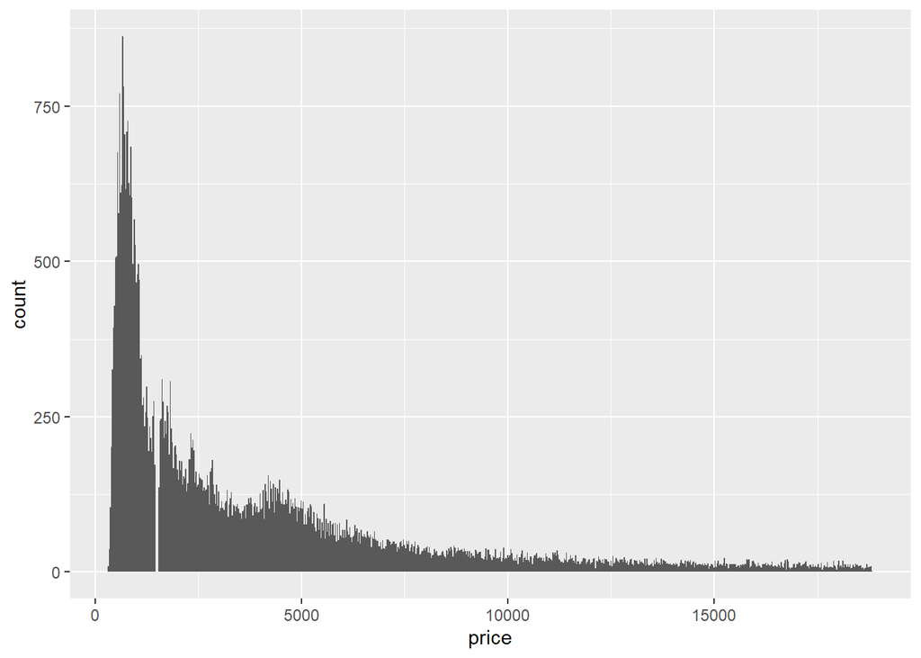

```r
diamonds |>
  ggplot(aes(x = price)) +
  geom_histogram(binwidth = 25)
```

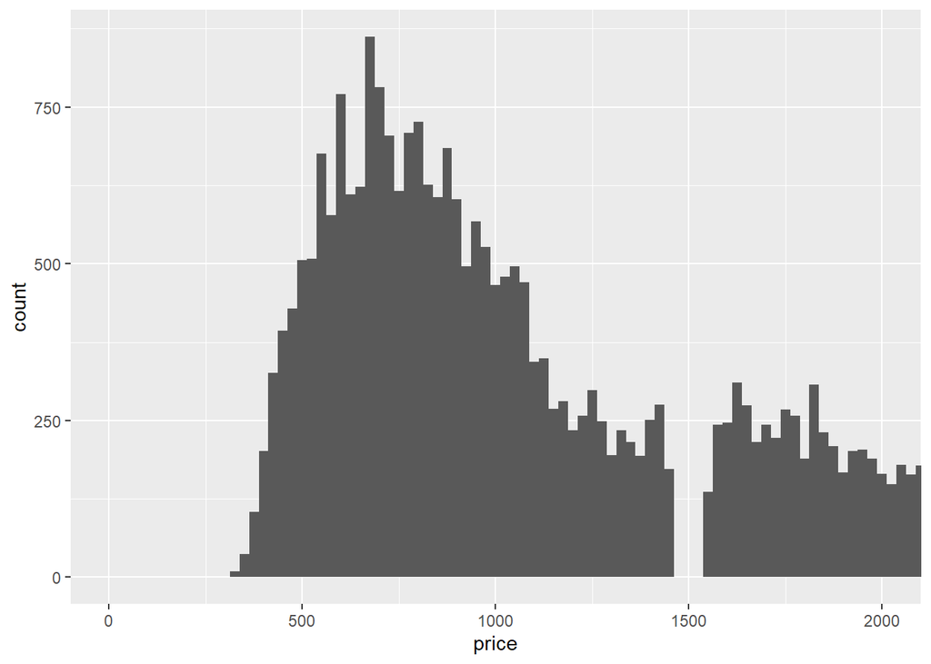

```r
diamonds |>
  ggplot(aes(x = price)) +
  geom_histogram(binwidth = 25) +
  coord_cartesian(xlim = c(0, 2000))
```

There are only 23 diamonds with a .99 carat, and 1558 with 1.00 carat.  
The definition of a carat is its weight, so perhaps diamonds are selected to be a certain weight after cutting.

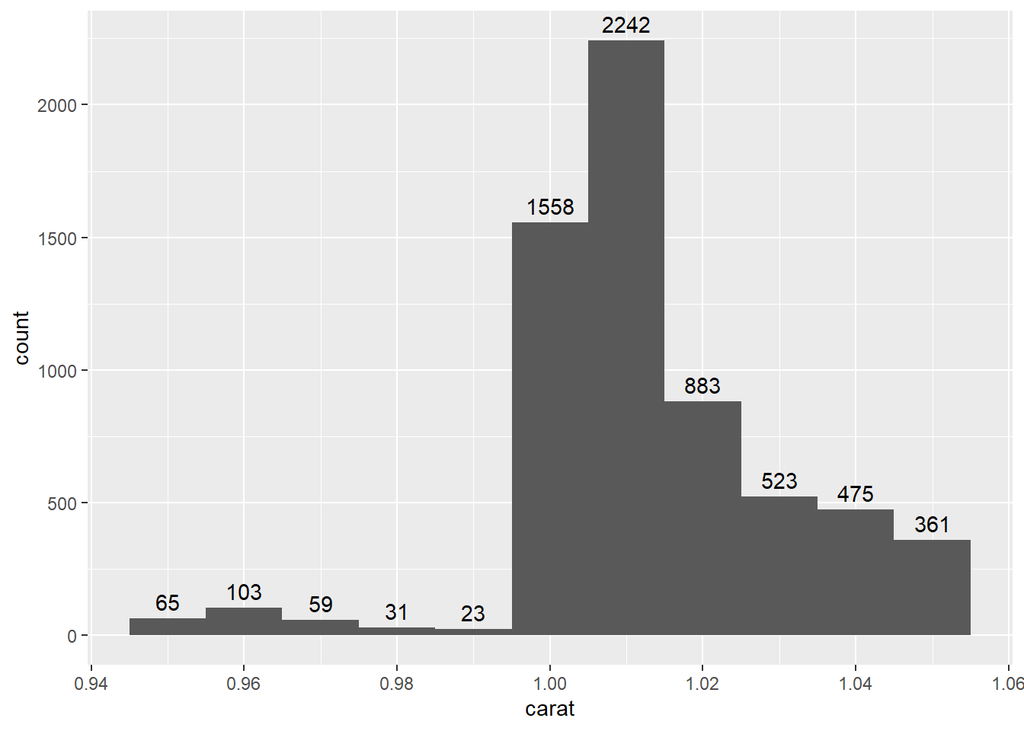

```r
diamonds |>
  filter(carat >= 0.95 & carat <= 1.05) |>
  ggplot(aes(x = carat)) +
  geom_histogram(binwidth = 0.01) +
  geom_text(
    stat = "bin",
    aes(label = after_stat(count)),
    binwidth = 0.01,
    vjust = -0.5
  )
```

While `xlim` converts all the values outside of its defined borders to `NA`, the `coord_cartesian` leaves the data untouched and only zooms.

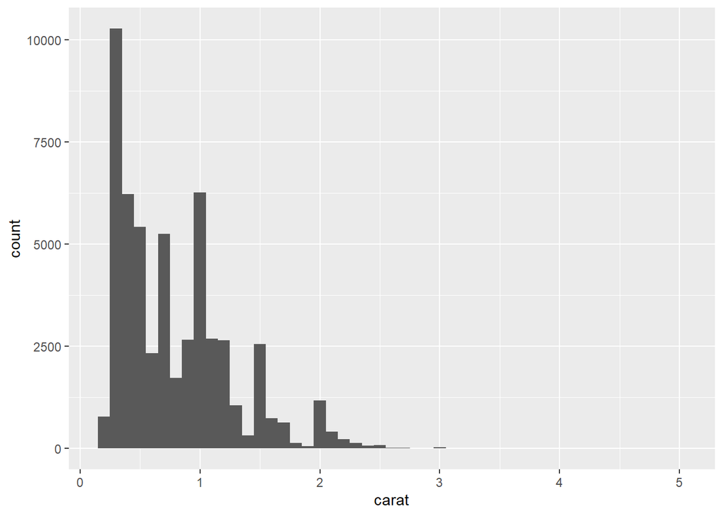

```r
diamonds |>
  ggplot() +
  geom_histogram(aes(x = carat), binwidth = .1) + #set bin width
  scale_x_continuous()
```

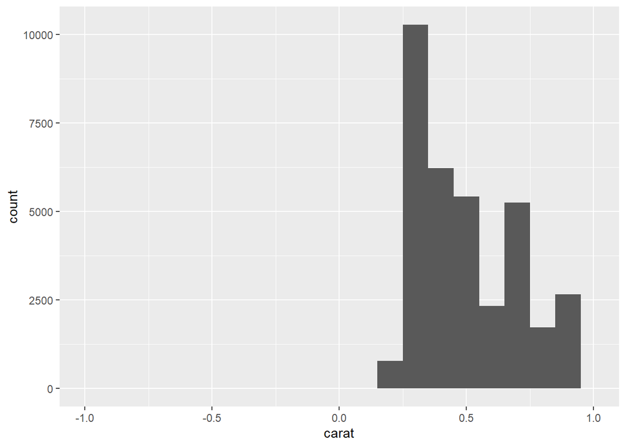

```r
diamonds |>
  ggplot() +
  geom_histogram(aes(x = carat), binwidth = .1) +  #set bin width
  scale_x_continuous(limits = c(-1, 1))
```

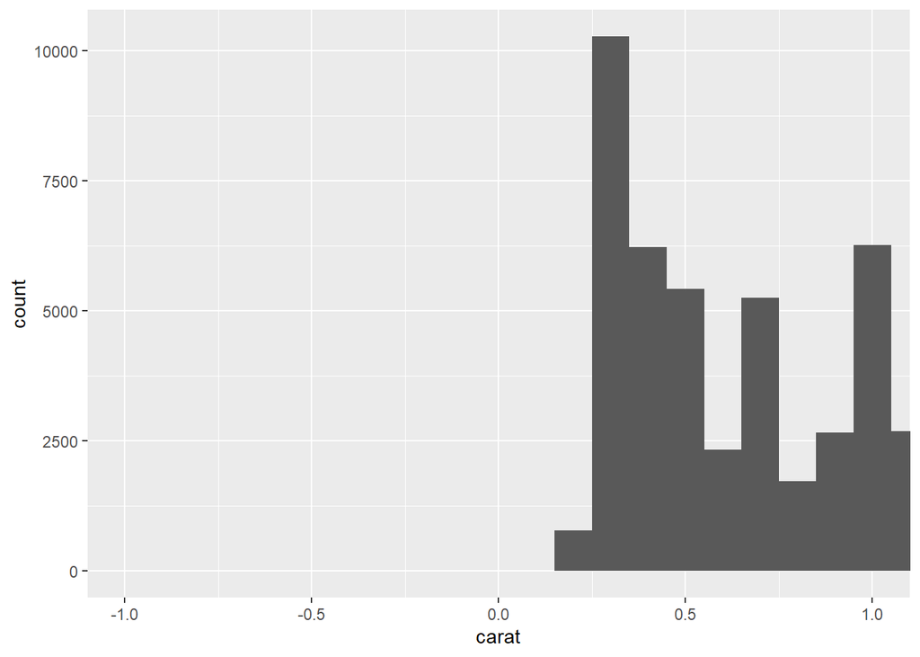

```r
diamonds |>
  ggplot() +
  geom_histogram(aes(x = carat), binwidth = .1) +  #set bin width
  coord_cartesian(xlim = c(-1, 1))
```

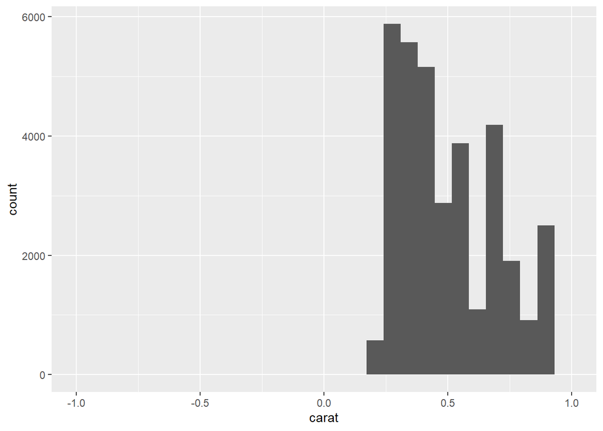

```r
diamonds |>
  ggplot() +
  geom_histogram(aes(x = carat)) +
  scale_x_continuous(limits = c(-1, 1))
```

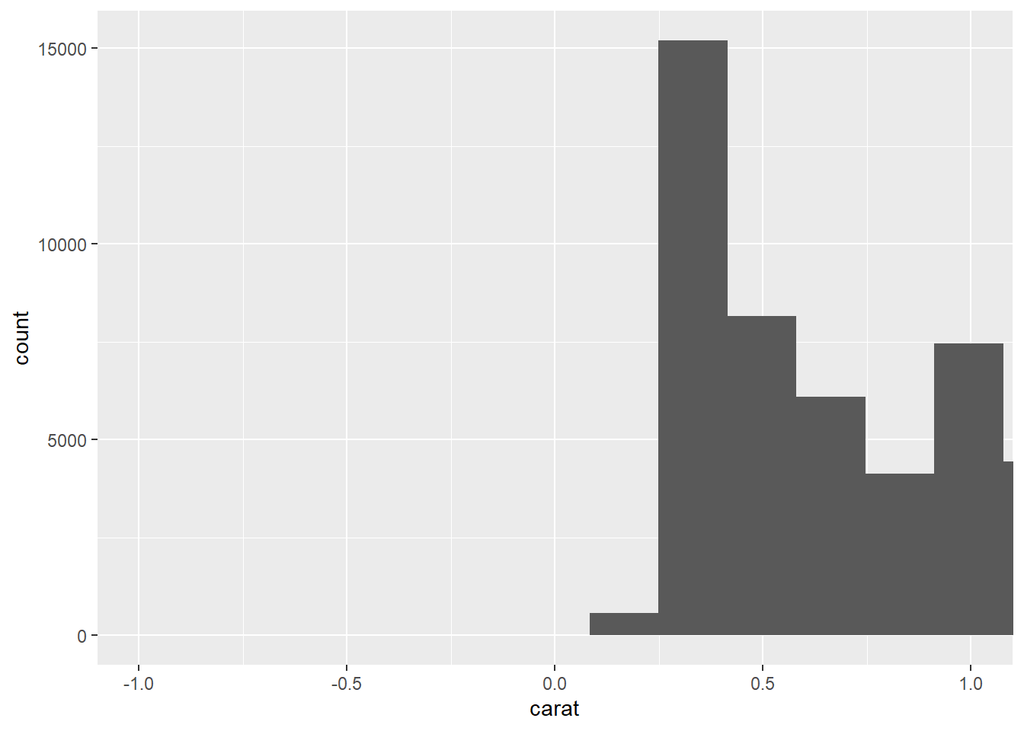

```r
diamonds |>
  ggplot() +
  geom_histogram(aes(x = carat)) +
  coord_cartesian(xlim = c(-1, 1))
```

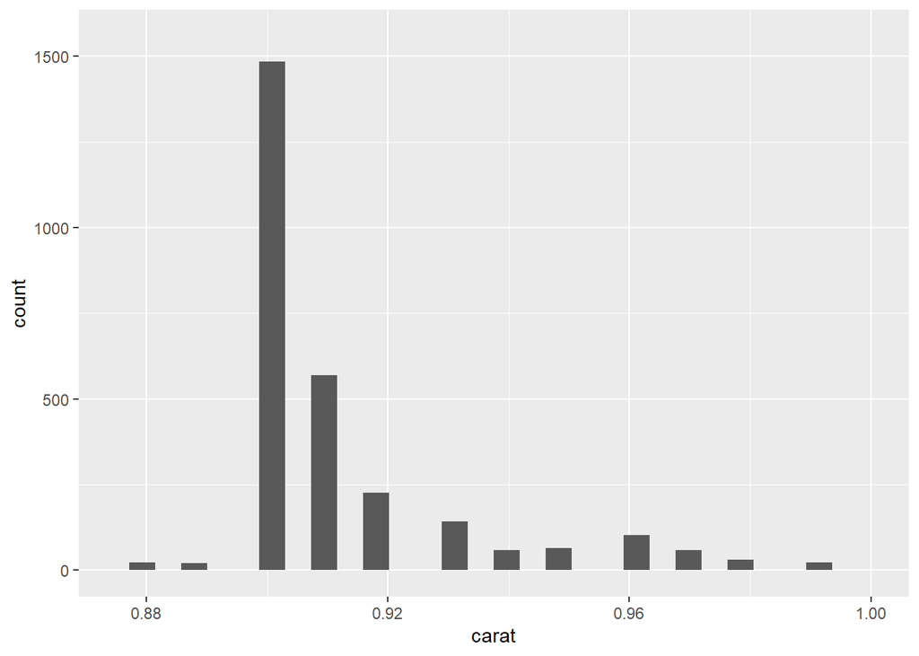

```r
diamonds |>
  ggplot() +
  geom_histogram(aes(x = carat)) +
  scale_x_continuous(limits = c(.875, 1))
```

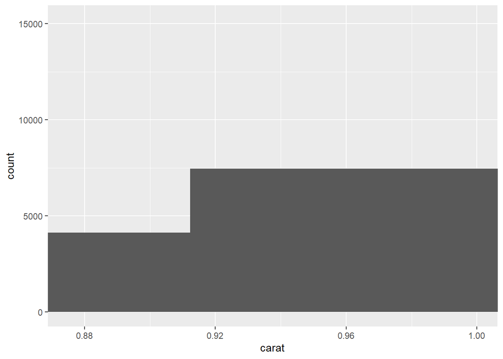

```r
diamonds |>
  ggplot() +
  geom_histogram(aes(x = carat)) +
  coord_cartesian(xlim = c(.875, 1))
```

### 11.4.1

`geom_histogram` and `geom_bar` both keeps NA as default. However, since they cannot be graphed, they are removed.

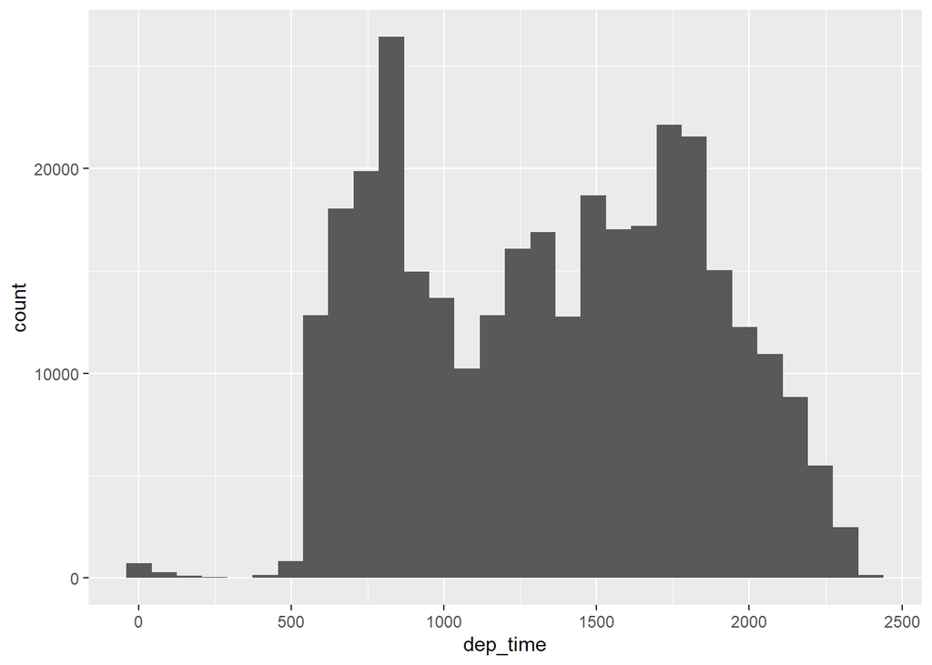

```r
flights |>
  ggplot(aes(x = dep_time)) +
  geom_histogram()
```

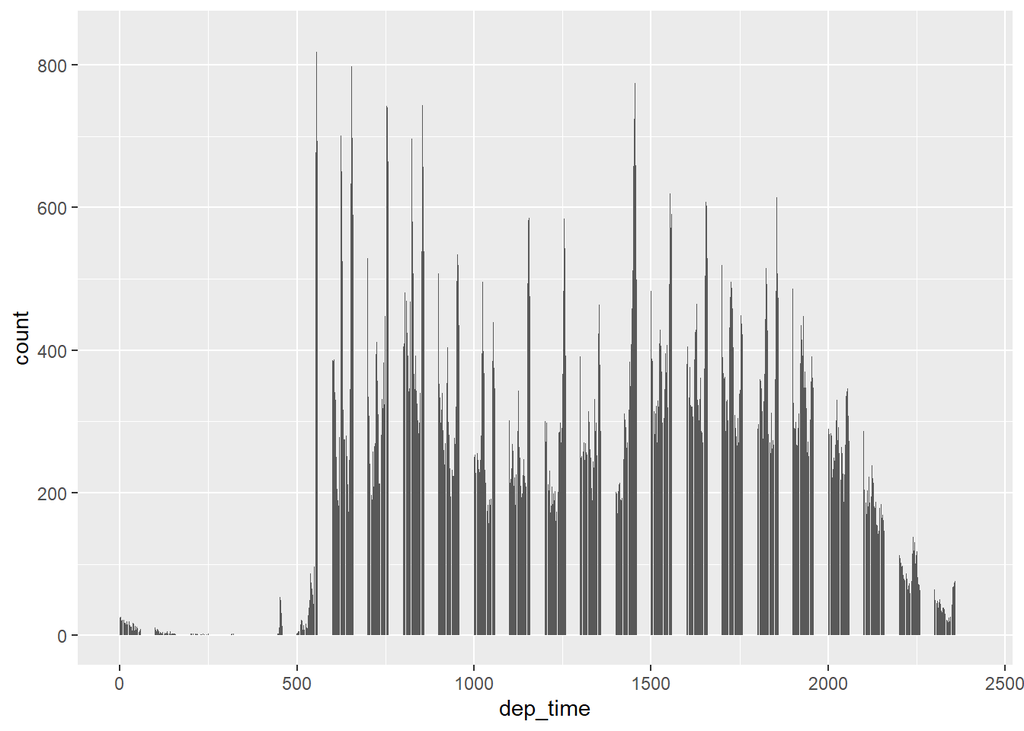

```r
flights |>
  ggplot(aes(x = dep_time)) +
  geom_bar()
```

`na.rm = TRUE` makes sure that the operation succeeds for `mean` and `sum`

```r
flights |>
  summarise(
    mean = mean(dep_time),
    sum = sum(dep_time)
  )
```

```
## # A tibble: 1 × 2
##    mean   sum
##   <dbl> <int>
## 1    NA    NA
```

```r
flights |>
  summarise(
    mean = mean(dep_time, na.rm = TRUE),
    sum = sum(dep_time, na.rm = TRUE)
  )
```

```
## # A tibble: 1 × 2
##    mean       sum
##   <dbl>     <int>
## 1 1349. 443210949
```

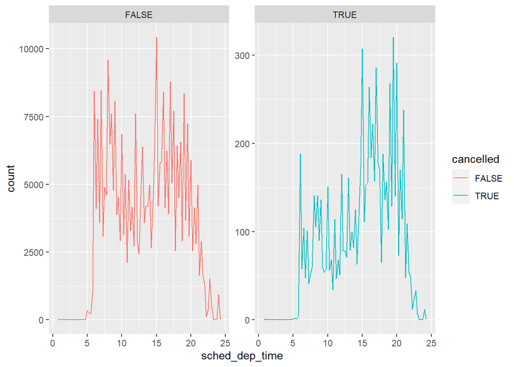

```r
nycflights13::flights |>
  mutate(
    cancelled = is.na(dep_time),
    sched_hour = sched_dep_time %/% 100,
    sched_min = sched_dep_time %% 100,
    sched_dep_time = sched_hour + (sched_min / 60)
  ) |>
  ggplot(aes(x = sched_dep_time)) +
  geom_freqpoly(aes(color = cancelled), binwidth = 1/4) +
  facet_wrap(~ cancelled, scales = "free_y")
```

### 11.5.1.1

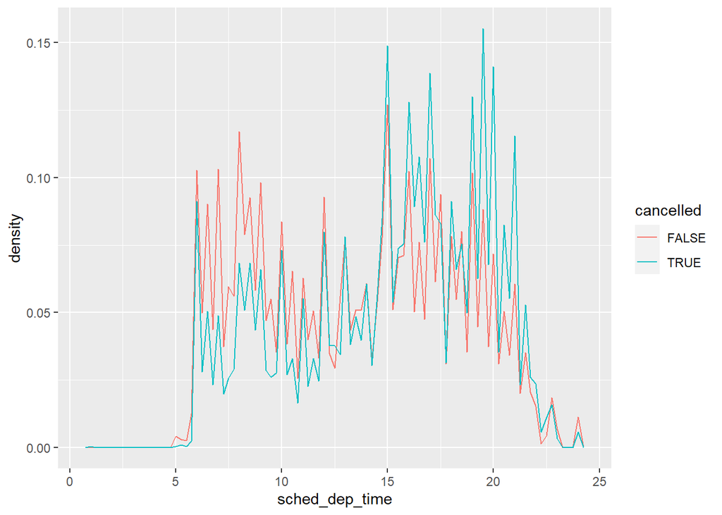

```r
nycflights13::flights |>
  mutate(
    cancelled = is.na(dep_time),
    sched_hour = sched_dep_time %/% 100,
    sched_min = sched_dep_time %% 100,
    sched_dep_time = sched_hour + (sched_min / 60)
  ) |>
  ggplot(aes(x = sched_dep_time, y = after_stat(density))) +
  geom_freqpoly(aes(color = cancelled), binwidth = 1/4)
```

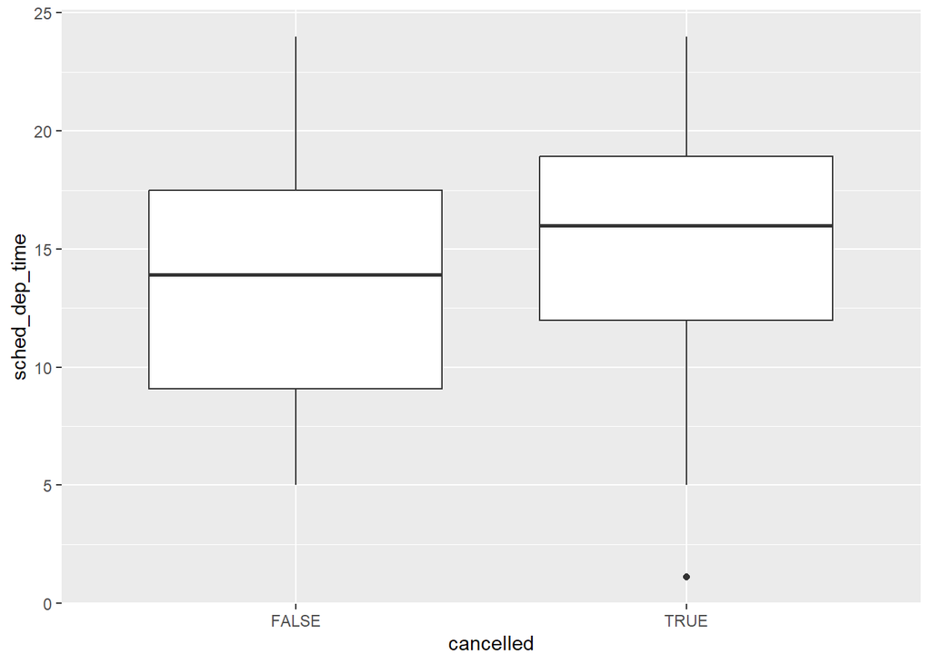

```r
nycflights13::flights |>
  mutate(
    cancelled = is.na(dep_time),
    sched_hour = sched_dep_time %/% 100,
    sched_min = sched_dep_time %% 100,
    sched_dep_time = sched_hour + (sched_min / 60)
  ) |>
  ggplot(aes(x = cancelled, y = sched_dep_time)) +
  geom_boxplot()
```

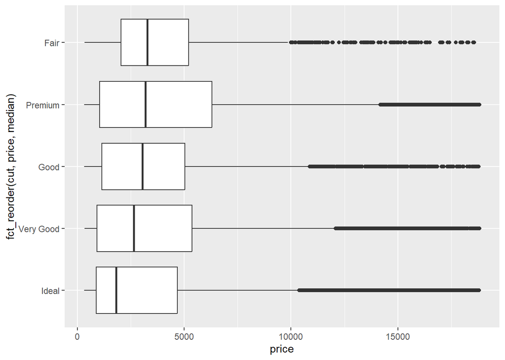

```r
diamonds |>
  ggplot(aes(x = price, y = fct_reorder(cut, price, median))) +
  geom_boxplot()
```

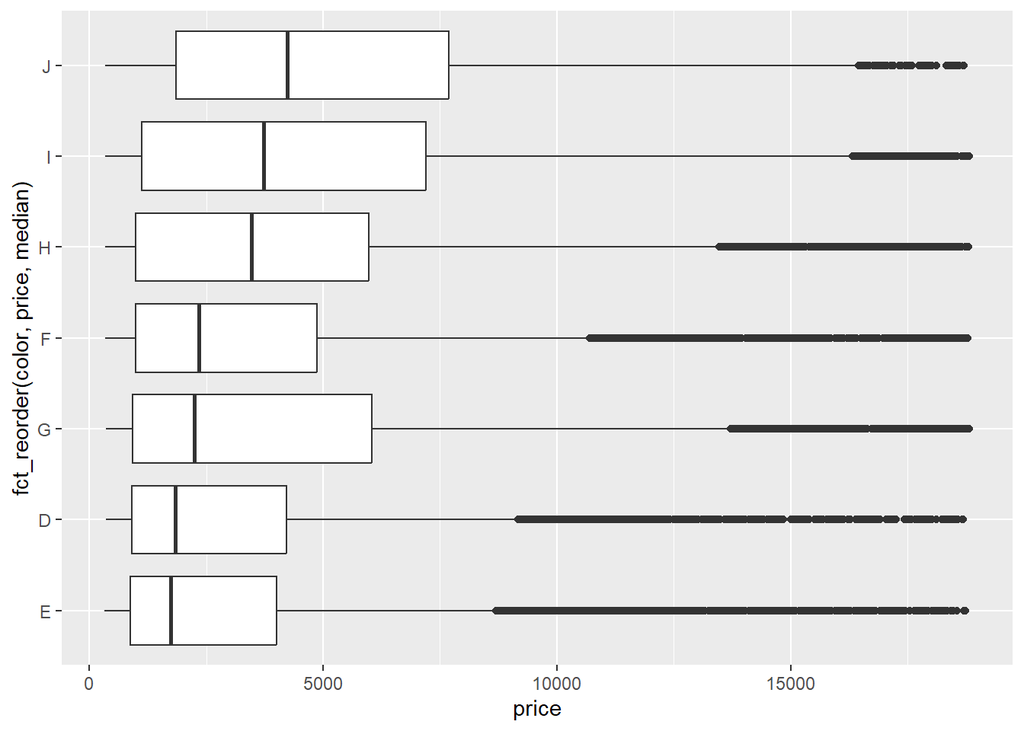

```r
diamonds |>
  ggplot(aes(x = price, y = fct_reorder(color, price, median))) +
  geom_boxplot()
```

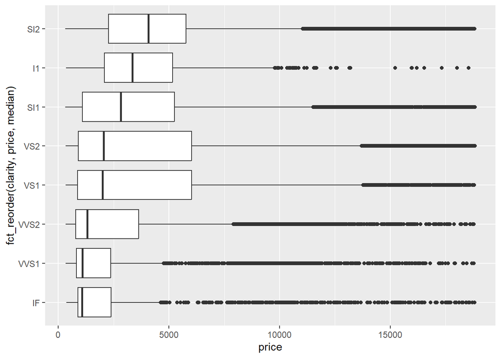

```r
diamonds |>
  ggplot(aes(x = price, y = fct_reorder(clarity, price, median))) +
  geom_boxplot()
```

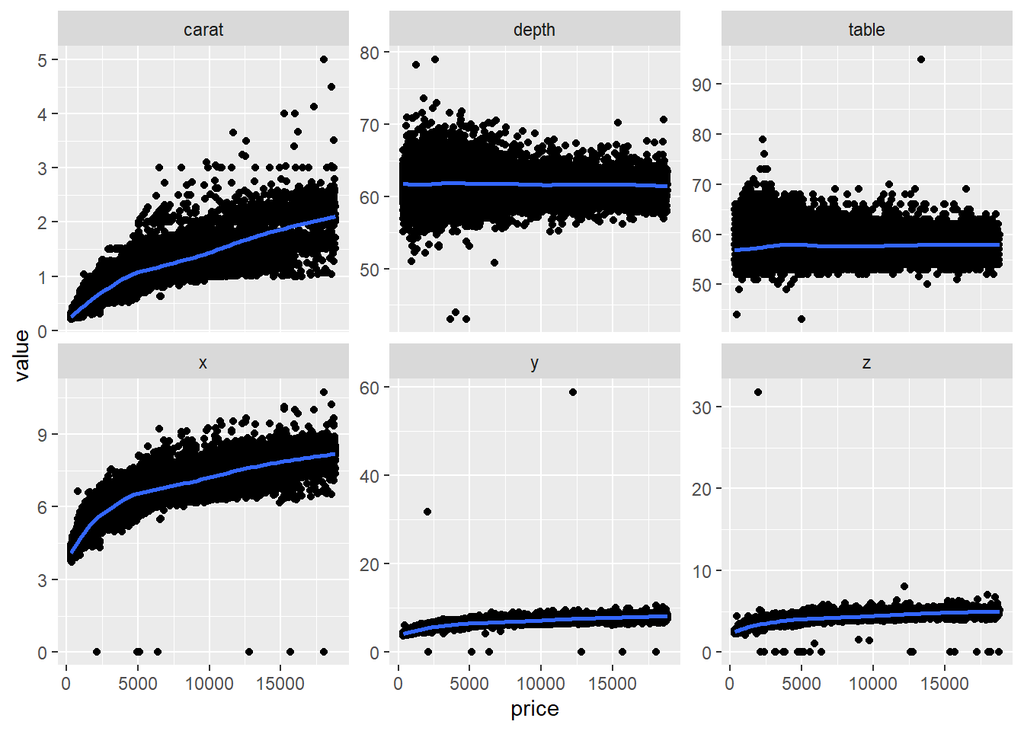

```r
diamonds |>
  relocate(price, .before = 1) |>
  relocate(carat, .after = clarity) |>
  pivot_longer(5:ncol(diamonds)) |>
  ggplot(aes(x = price, y = value)) +
  geom_point() +
  geom_smooth() +
  facet_wrap(~ name, scales = "free_y")
```

It seems that `carat` correlates the best with `price` - plotting against `cut` we can see that the fair diamonds tend to be the heaviest.

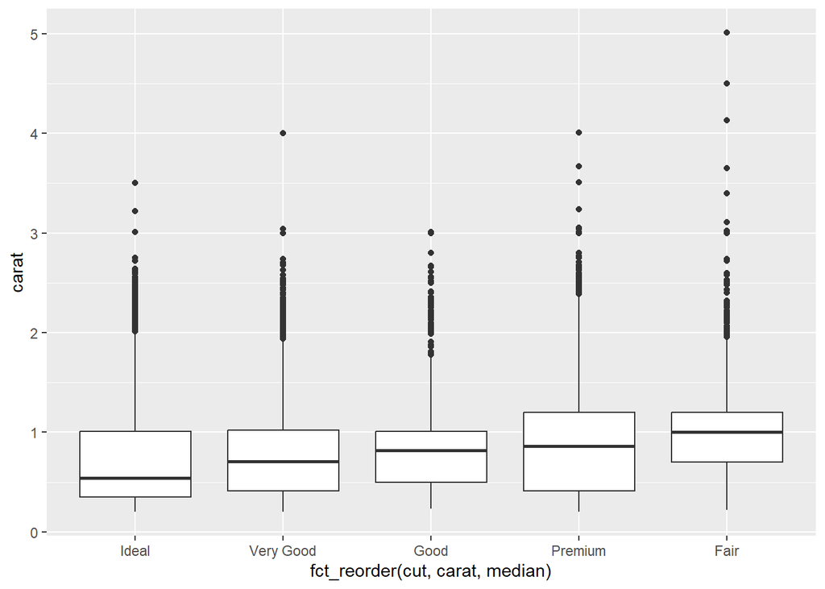

```r
diamonds |>
  ggplot(aes(x = fct_reorder(cut, carat, median), y = carat)) +
  geom_boxplot()
```

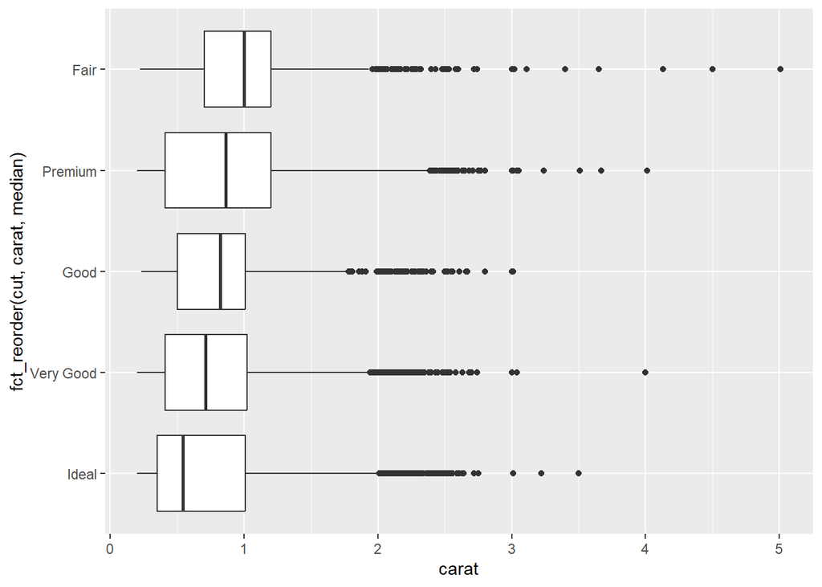

```r
diamonds |>
  ggplot(aes(x = fct_reorder(cut, carat, median), y = carat)) +
  geom_boxplot() +
  coord_flip()
```

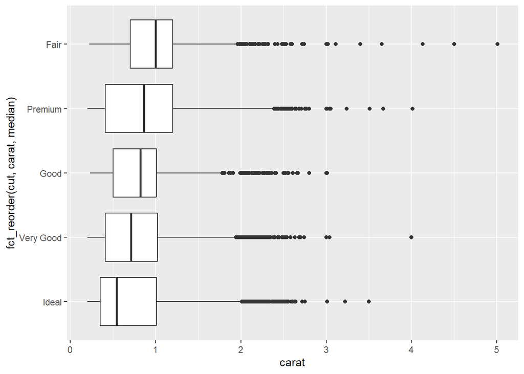

```r
diamonds |>
  ggplot(aes(y = fct_reorder(cut, carat, median), x = carat)) +
  geom_boxplot()
```

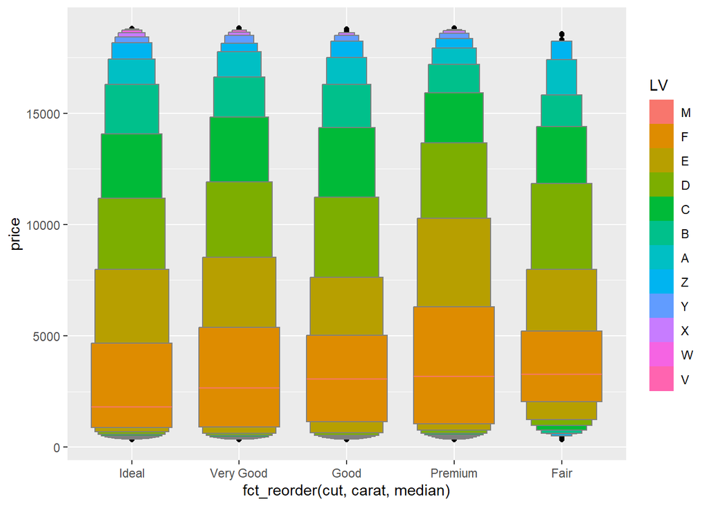

```r
diamonds |>
  ggplot(aes(x = fct_reorder(cut, carat, median), y = price)) +
  geom_lv(aes(fill = after_stat(LV)))
```

From `?geom_violin`: `A violin plot is a compact display of a continuous distribution. It is a blend of geom_boxplot() and geom_density(): a violin plot is a mirrored density plot displayed in the same way as a boxplot.`

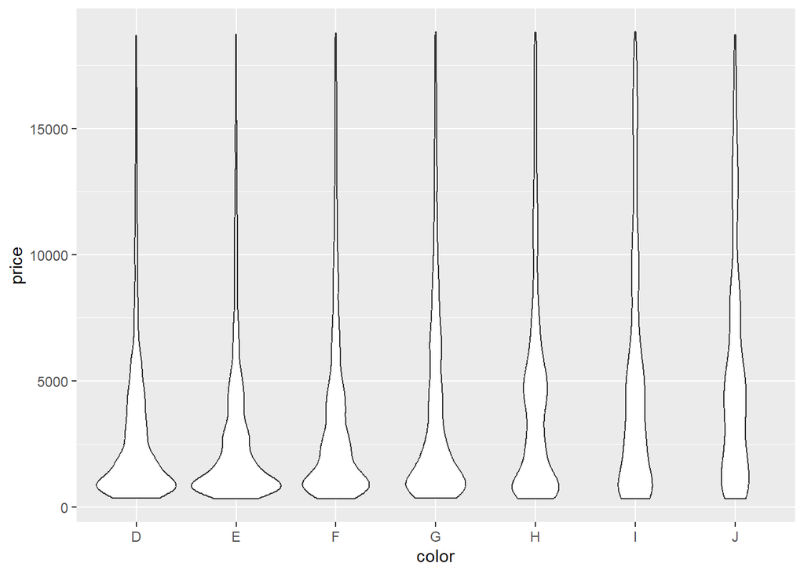

```r
diamonds |>
  ggplot(aes(x = color, y = price)) +
  geom_violin()
```

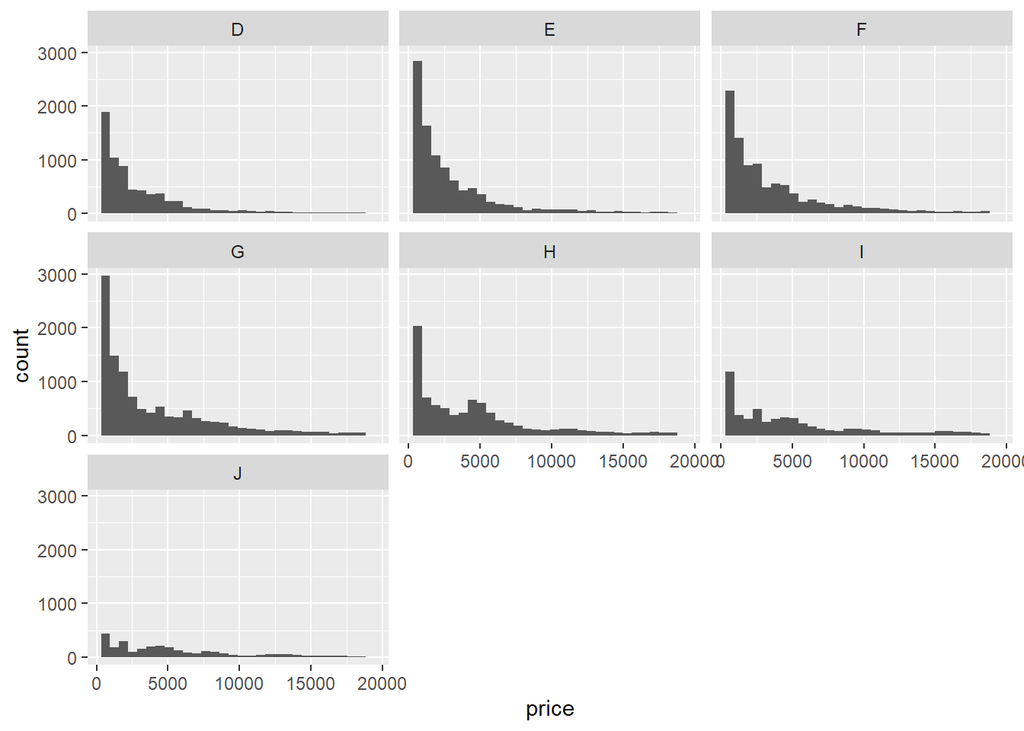

```r
diamonds |>
  ggplot(aes(x = price)) +
  geom_histogram() +
  facet_wrap(~ color)
```

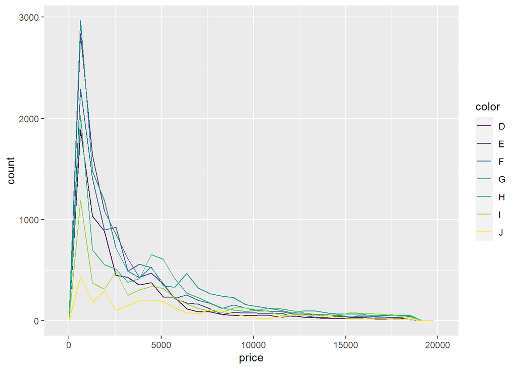

```r
diamonds |>
  ggplot(aes(x = price, color = color)) +
  geom_freqpoly()
```

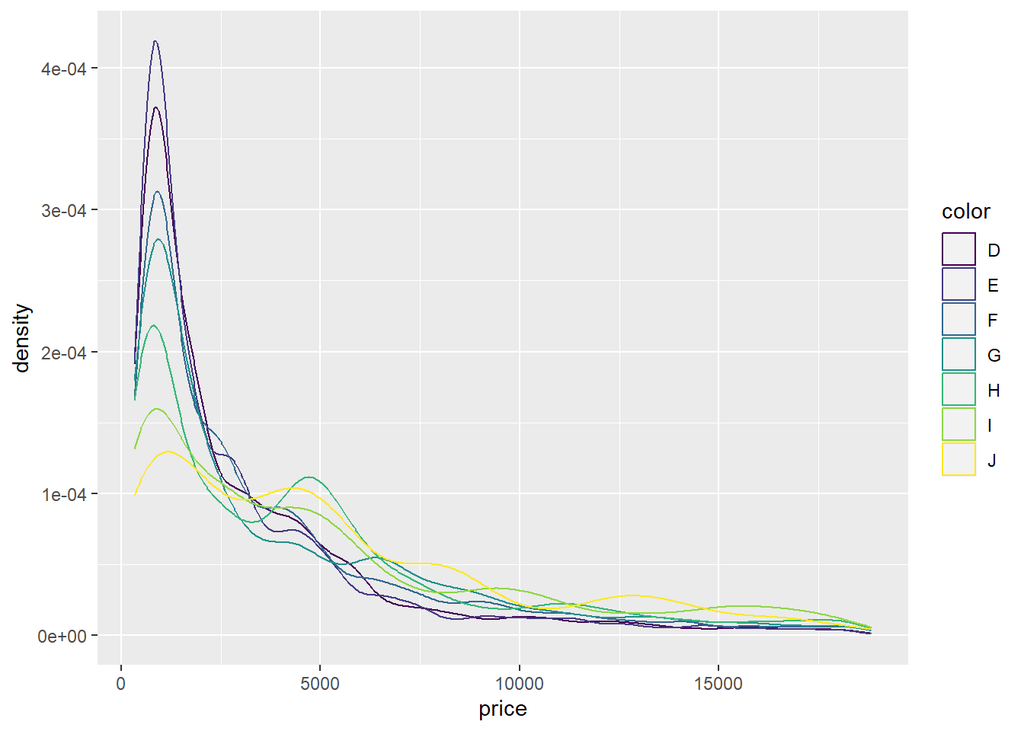

```r
diamonds |>
  ggplot(aes(x = price, color = color)) +
  geom_density()
```

`geom_quasirandom` avoids overlapping by using a van der Corput sequence or Tukeys texturing. `geom_beeswarm` does point-size based offset.

### 11.5.2.1

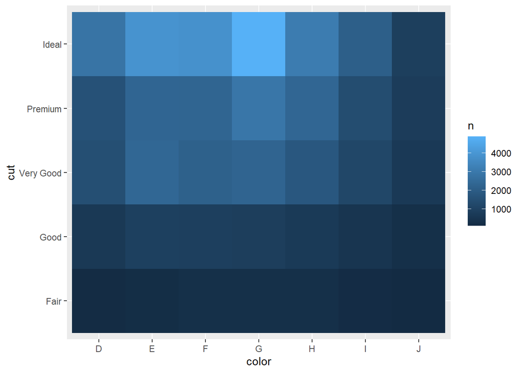

```r
diamonds.summary <- diamonds |>
  count(color, cut) |>
  group_by(cut) |>
  mutate(freq_cut = n / sum(n)) |>
  group_by(color) |>
  mutate(freq_color = n / sum(n))


  ggplot(data = diamonds.summary, aes(x = color, y = cut)) +
  geom_tile(aes(fill = n))
```

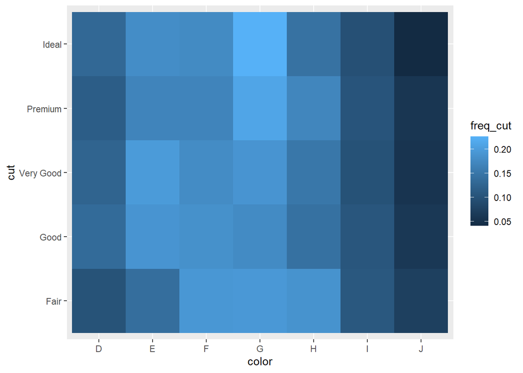

```r
  ggplot(data = diamonds.summary, aes(x = color, y = cut)) +
  geom_tile(aes(fill = freq_cut))
```

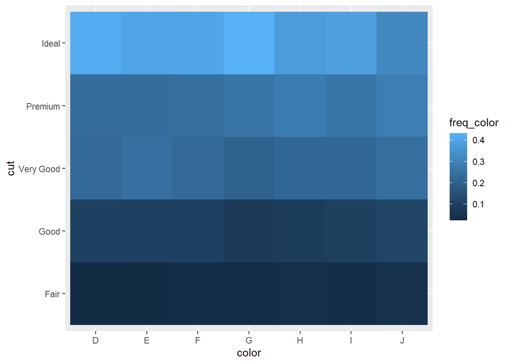

```r
  ggplot(data = diamonds.summary, aes(x = color, y = cut)) +
  geom_tile(aes(fill = freq_color))
```

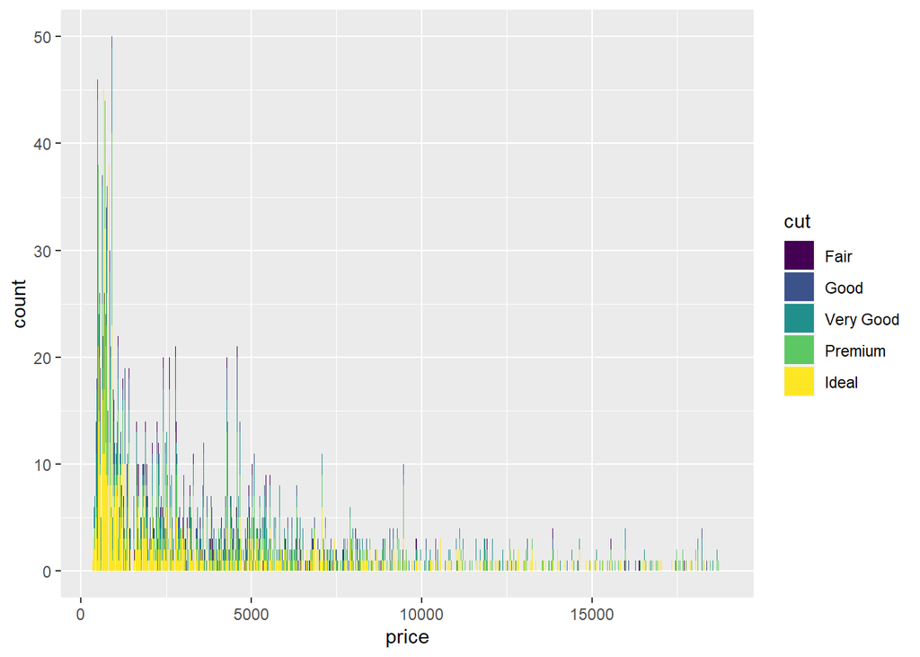

```r
diamonds |>
  ggplot(aes(x = price, color = x, fill = cut)) +
  geom_bar() +
  scale_y_continuous(limits = c(0,50))
```

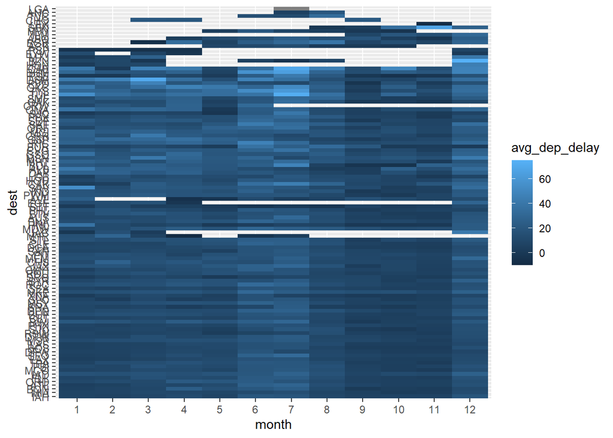

```r
flights |>
  mutate(month = as_factor(month),
         dest = as_factor(dest)
  ) |>
  relocate(month, dest, .before = 1) |>
  group_by(month, dest) |>
  summarise(
    avg_dep_delay = mean(dep_delay, na.rm = TRUE),
    .groups = "drop"
  ) |>
  ggplot(aes(x = month, y = dest, fill = avg_dep_delay)) +
  geom_tile()
```

### 11.5.3.1

`cut_width` sets the bin width to a specific number, `cut_number` divides the data into a specific number of bins.

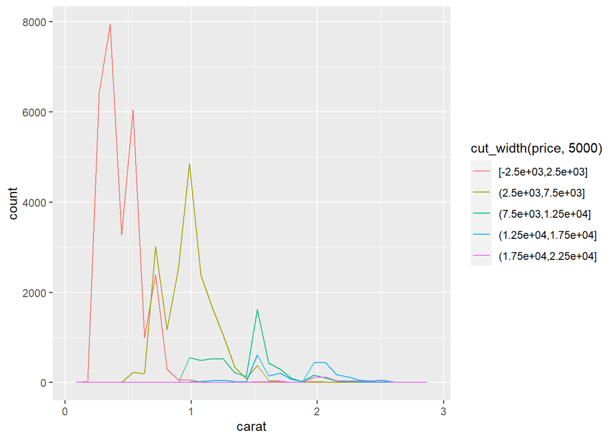

```r
diamonds |>
  filter(carat < 3) |>
  ggplot(
    aes(
    x = carat,
    color = cut_width(price, 5000)
    )
  ) +
  geom_freqpoly()
```

The prices follows the carat (weight), which is as I expect based on our other analysis.

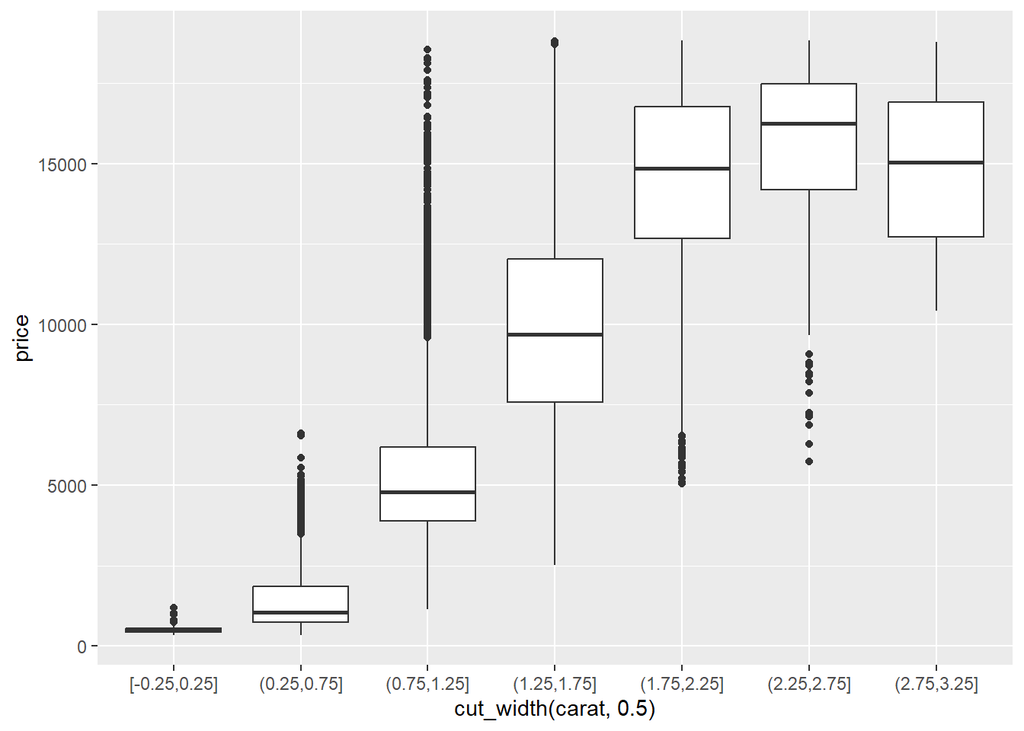

```r
diamonds |>
  filter(carat < 3) |>
  ggplot(
    aes(
      x = cut_width(carat, 0.5),
      y = price
    )
  ) +
  geom_boxplot()
```

Plotting of individual values is better for picking out outliers, because they are empasized against the majority of cases that correlate. A binned summary graph would not show outliers as clearly, if at all.

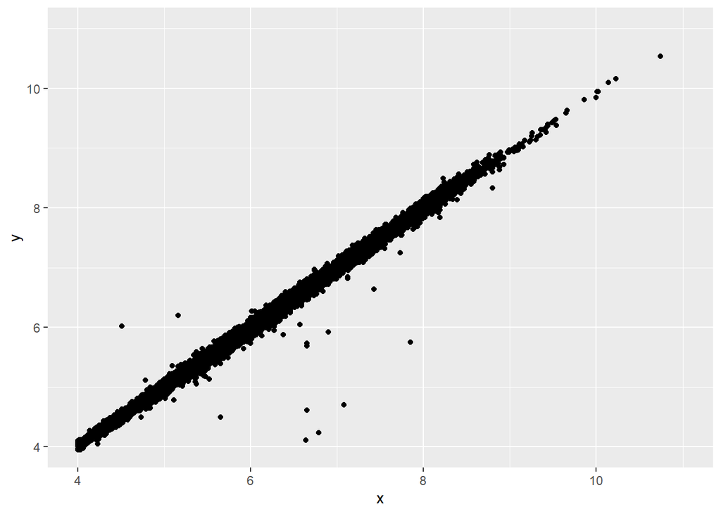

```r
diamonds |>
  filter(x >= 4) |>
  ggplot(aes(x = x, y = y)) +
  geom_point() +
  coord_cartesian(xlim = c(4, 11), ylim = c(4, 11))
```

As can be seen in this graph, by enforcing a certain number of observations we better understand the underlying data:

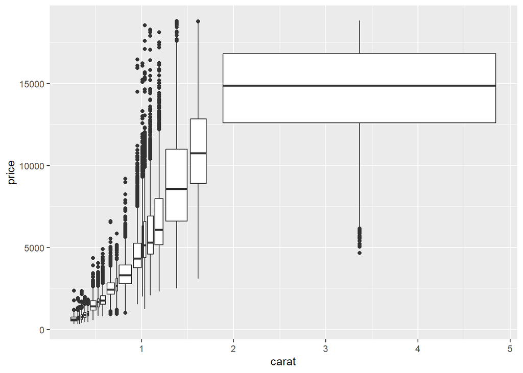

```r
diamonds |>
  filter(x >= 4) |>
  ggplot(aes(x = carat, y = price)) +
  geom_boxplot(aes(group = cut_number(carat, 20)))
```